# Tips analysis

### Data preprocessing

```python
# Importing neccessary packages
import seaborn as sns
import numpy as np
import matplotlib.pyplot as plt
from matplotlib.pyplot import pie, axis, show
from pandas import DataFrame
```

```python
# Loading the dataset
tips = sns.load_dataset("tips")
```

```python
# Checking the structure of tips dataset.
type(tips)
```

```
pandas.core.frame.DataFrame
```

```python
# Having an overview of
tips.head()
```

|  | total_bill | tip | sex | smoker | day | time | size |
| --- | --- | --- | --- | --- | --- | --- | --- |
| 0 | 16.99 | 1.01 | Female | No | Sun | Dinner | 2 |
| 1 | 10.34 | 1.66 | Male | No | Sun | Dinner | 3 |
| 2 | 21.01 | 3.50 | Male | No | Sun | Dinner | 3 |
| 3 | 23.68 | 3.31 | Male | No | Sun | Dinner | 2 |
| 4 | 24.59 | 3.61 | Female | No | Sun | Dinner | 4 |

```python
# Getting information about the data
tips.info()
```

```
<class 'pandas.core.frame.DataFrame'>
RangeIndex: 244 entries, 0 to 243
Data columns (total 7 columns):
 #   Column      Non-Null Count  Dtype
---  ------      --------------  -----
 0   total_bill  244 non-null    float64
 1   tip         244 non-null    float64
 2   sex         244 non-null    category
 3   smoker      244 non-null    category
 4   day         244 non-null    category
 5   time        244 non-null    category
 6   size        244 non-null    int64
dtypes: category(4), float64(2), int64(1)
memory usage: 7.4 KB
```

### Data Modelling

> I will be creating the following columns for the purpose of analysis:
- tip_ratio - ratio of tip to bill,
- sum - the sum of total bill and tip
- percent - tip as a percent of sum,
- bpp - amount of total bill divided by number of people in the group,
- tpp - amount of tip per person.

```python
# new column created - percent of tip
tips["tip_ratio"] = tips["tip"]/tips["total_bill"]

# new column created - sum of total bill and tip
tips["sum"] = tips["total_bill"]+tips["tip"] # appended at the end of the array

# new column created - ratio of tip to sum
tips["percent"] = round(tips["tip"]/tips["sum"]*100, 2)

# add column: bpp - bill per person
tips["bpp"] = tips["total_bill"]/tips["size"]

# add column: tpp - tip per person
tips["tpp"] = tips["tip"]/tips["size"]
```

```python
# Checking if the columns were sucessfully added
tips.head()
```

|  | total_bill | tip | sex | smoker | day | time | size | tip_ratio | sum | percent | bpp | tpp |
| --- | --- | --- | --- | --- | --- | --- | --- | --- | --- | --- | --- | --- |
| 0 | 16.99 | 1.01 | Female | No | Sun | Dinner | 2 | 0.059447 | 18.00 | 5.61 | 8.495000 | 0.505000 |
| 1 | 10.34 | 1.66 | Male | No | Sun | Dinner | 3 | 0.160542 | 12.00 | 13.83 | 3.446667 | 0.553333 |
| 2 | 21.01 | 3.50 | Male | No | Sun | Dinner | 3 | 0.166587 | 24.51 | 14.28 | 7.003333 | 1.166667 |
| 3 | 23.68 | 3.31 | Male | No | Sun | Dinner | 2 | 0.139780 | 26.99 | 12.26 | 11.840000 | 1.655000 |
| 4 | 24.59 | 3.61 | Female | No | Sun | Dinner | 4 | 0.146808 | 28.20 | 12.80 | 6.147500 | 0.902500 |

### Data analysis and exploration

```python
# Getting the numerical summary of the data.
tips.describe()
```

|  | total_bill | tip | size | tip_ratio | sum | percent | bpp | tpp |
| --- | --- | --- | --- | --- | --- | --- | --- | --- |
| count | 244.000000 | 244.000000 | 244.000000 | 244.000000 | 244.000000 | 244.000000 | 244.00000 | 244.000000 |
| mean | 19.785943 | 2.998279 | 2.569672 | 0.160803 | 22.784221 | 13.643320 | 7.88823 | 1.212762 |
| std | 8.902412 | 1.383638 | 0.951100 | 0.061072 | 9.890116 | 4.058544 | 2.91435 | 0.491705 |
| min | 3.070000 | 1.000000 | 1.000000 | 0.035638 | 4.070000 | 3.440000 | 2.87500 | 0.400000 |
| 25% | 13.347500 | 2.000000 | 2.000000 | 0.129127 | 15.475000 | 11.437500 | 5.80250 | 0.862500 |
| 50% | 17.795000 | 2.900000 | 2.000000 | 0.154770 | 20.600000 | 13.405000 | 7.25500 | 1.107500 |
| 75% | 24.127500 | 3.562500 | 3.000000 | 0.191475 | 27.722500 | 16.070000 | 9.39000 | 1.500000 |
| max | 50.810000 | 10.000000 | 6.000000 | 0.710345 | 60.810000 | 41.530000 | 20.27500 | 3.333333 |

[output not shown]

[figure not shown]

```python
## Getting the graphical summary of the data.
tips.hist(figsize=(20,16))
```

- The highest amount customers paid(excluding the tips) in the resturant was 50.81 Euros and the minimum amount was 3.07 Euros.
- The maximum amount of tips paid by customer was 10 Euros while the minimum tip paid was 1 euros.
- On average, the percent of tip is 13.64%.
- On average, total bill split equally in the group is 7.89.
- On average, tip per person is 1.21.

```python
# Getting the proportion of gender
print(tips.sex.value_counts())
```

```
Male      157
Female     87
Name: sex, dtype: int64
```

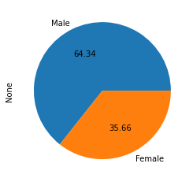

```python
tips.groupby('sex').size().plot(kind='pie', autopct='%.2f')
```

> The resturant has more male customers than the females, with 64.34% and 35.66% respectively.

```python
# Getting the unique values that's in the smoker column
print(tips.smoker.value_counts())
```

```
No     151
Yes     93
Name: smoker, dtype: int64
```

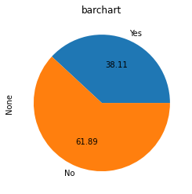

```python
tips.groupby('smoker').size().plot(kind='pie', autopct='%.2f', title = "barchart")
```

> Non-smokers patronizes the resturants more than the smokers with a percetange of 61.89 and 38.11 respectively.

```python
print("Unique values in column 'day':\t", sorted(tips.day.unique()))
print("Unique values in column 'time':\t", sorted(tips.time.unique()))
```

```
Unique values in column 'day':	 ['Fri', 'Sat', 'Sun', 'Thur']
Unique values in column 'time':	 ['Dinner', 'Lunch']
```

> It appears the resutarnt only opens on Thursday, Friday, Saturday and Sunday and offers their services at either lunch or dinner time.

```
<BarContainer object of 4 artists>
```

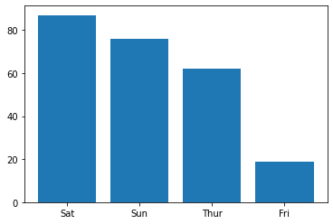

```python
# Plotting a bar chart to determine the day which tips are mostly paid
plt.bar(tips['day'].value_counts().index,tips['day'].value_counts().values)
```

> Tips are mostly paid on Saturdays.

```
<BarContainer object of 2 artists>
```

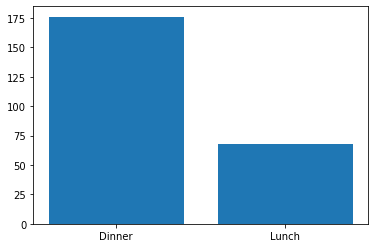

```python
# Plotting a bar chart to dermine which period was tip mostly paid
plt.bar(tips['time'].value_counts().index,tips['time'].value_counts().values)
```

> Tips was mostly paid during the dinner period

```python
### I want to compare the average of tip per smoker and non-smoker

# mean tip per smoking person
print("Average tip per smoker:\t\t\t", tips[tips["smoker"] == "Yes"]["tpp"].mean()) # filtering by applying conditional check (smoker=yes)

# mean total bill among smokers
print("Average total bill among smokers:\t\t", tips[tips["smoker"] == "Yes"]["total_bill"].mean())

# Tip ratio among smokers
tips["ratio_smoke"] = tips[tips["smoker"] == "Yes"]["tip"] / tips[tips["smoker"] == "Yes"]["total_bill"]
print("Ratio of tips to total bill among smokers:\t", tips["ratio_smoke"].mean())


# mean tip per smoking person
print("Average tip per non-smoker:\t\t\t", tips[tips["smoker"] == "No"]["tpp"].mean()) # filtering by applying conditional check (smoker=yes)

# mean total bill among smokers
print("Average total bill among non-smokers:\t\t", tips[tips["smoker"] == "No"]["total_bill"].mean())

# mean ratio among smokers
tips["ratio_nonsmoker"] = tips[tips["smoker"] == "No"]["tip"] / tips[tips["smoker"] == "No"]["total_bill"]
print("Ratio of tips to total bill among non- smokers:\t", tips["ratio_nonsmoker"].mean())
```

```
Average tip per smoker:			 1.2977956989247312
Average total bill among smokers:		 20.756344086021507
Ratio of tips to total bill among smokers:	 0.1631960446368779
Average tip per non-smoker:			 1.1603896247240624
Average total bill among non-smokers:		 19.18827814569537
Ratio of tips to total bill among non- smokers:	 0.1593284621792153
```

> The smokers pay more for the service as well as give higher tips. On average the ratio tip to total bill among smokers is approximately 16.32%

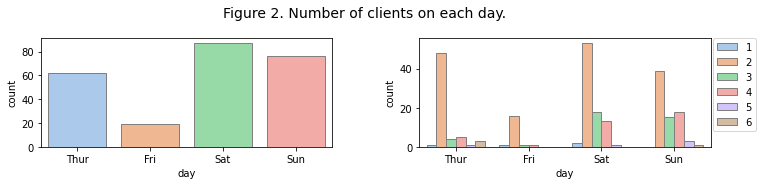

```python
# Creating plots to show the number of customers split into days the restaurant was open and the size of the party

# Display setting
fig, ax = plt.subplots(ncols=2, figsize=(12, 2))
plt.suptitle("Figure 2. Number of clients on each day.", y=1.1, fontsize=14)
plt.subplots_adjust(left=None, bottom=None, right=None, top=None, wspace=.3, hspace=None)

# plot data and propertiesy
sns.countplot(data=tips, x="day", palette="pastel", edgecolor=".5", ax=ax[0]) # number of clients on each day
sns.countplot(data=tips, x="day", palette="pastel", edgecolor=".5", hue='size', ax=ax[1]) # additional discrimination on party size
plt.legend(bbox_to_anchor=(1.01, 1), loc=2, borderaxespad=0.) # Put the legend out of the figure, taken from https://stackoverflow.com/a/34579525

plt.show()
```

> There are more cutomers on Saturdays and the party size is mostly 2 accross all days

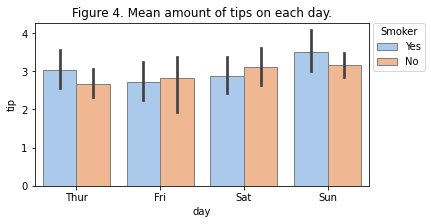

```python
# Creating a bar plot that displays the amount of tip offered each day, categorized by smoker and non-smokers.

# adapted from https://medium.com/@neuralnets/data-visualization-with-python-and-seaborn-part-1-29c9478a8700
fig, ax = plt.subplots(ncols=1, figsize=(6,3))
plt.title('Figure 4. Mean amount of tips on each day.')

# Mean amount of tip on each day
sns.barplot(data = tips, x = "day", y = "tip", hue="smoker", palette="pastel", edgecolor=".5")
plt.legend(bbox_to_anchor=(1.01, 1), loc=2, borderaxespad=0.0, title="Smoker") # legend put outside of the plot area

plt.show()
```

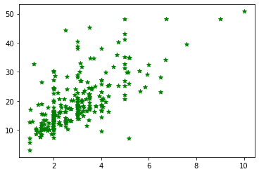

```python
# Creating a scatter to see if there is relaltionship between tips and total bills paid
plt.figure()
plt.scatter(tips.tip,tips.total_bill,color='g',marker='*')
```

> There seem to be a positive linear relationship between tips and total bills.

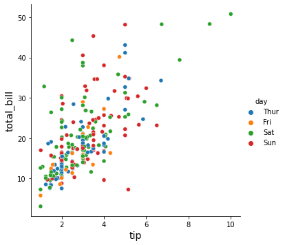

```python
# Creating a scattter plot to determine between bills and total_bills using days as a factor
sns.relplot(x="tip", y="total_bill", data=tips, hue='day')
plt.xlabel('tip',fontsize=14)
plt.ylabel('total_bill',fontsize=14);
```

> Days of opening does not affect the positive relatinshop between tips and total bills. From the plot, it can also be seen that the highest tips was paid on a Saturday.

```python
# Subsetting the data to have only female customers
Female_tips = tips.loc[tips.sex == 'Female']
Female_tips.head()
```

|  | total_bill | tip | sex | smoker | day | time | size | tip_ratio | sum | percent | bpp | tpp | ratio_smoke | ratio_nonsmoker |
| --- | --- | --- | --- | --- | --- | --- | --- | --- | --- | --- | --- | --- | --- | --- |
| 0 | 16.99 | 1.01 | Female | No | Sun | Dinner | 2 | 0.059447 | 18.00 | 5.61 | 8.495000 | 0.505000 | NaN | 0.059447 |
| 4 | 24.59 | 3.61 | Female | No | Sun | Dinner | 4 | 0.146808 | 28.20 | 12.80 | 6.147500 | 0.902500 | NaN | 0.146808 |
| 11 | 35.26 | 5.00 | Female | No | Sun | Dinner | 4 | 0.141804 | 40.26 | 12.42 | 8.815000 | 1.250000 | NaN | 0.141804 |
| 14 | 14.83 | 3.02 | Female | No | Sun | Dinner | 2 | 0.203641 | 17.85 | 16.92 | 7.415000 | 1.510000 | NaN | 0.203641 |
| 16 | 10.33 | 1.67 | Female | No | Sun | Dinner | 3 | 0.161665 | 12.00 | 13.92 | 3.443333 | 0.556667 | NaN | 0.161665 |

```
array([[<AxesSubplot:title={'center':'total_bill'}>,
        <AxesSubplot:title={'center':'tip'}>,
        <AxesSubplot:title={'center':'size'}>],
       [<AxesSubplot:title={'center':'tip_ratio'}>,
        <AxesSubplot:title={'center':'sum'}>,
        <AxesSubplot:title={'center':'percent'}>],
       [<AxesSubplot:title={'center':'bpp'}>,
        <AxesSubplot:title={'center':'tpp'}>,
        <AxesSubplot:title={'center':'ratio_smoke'}>],
       [<AxesSubplot:title={'center':'ratio_nonsmoker'}>, <AxesSubplot:>,
        <AxesSubplot:>]], dtype=object)
```

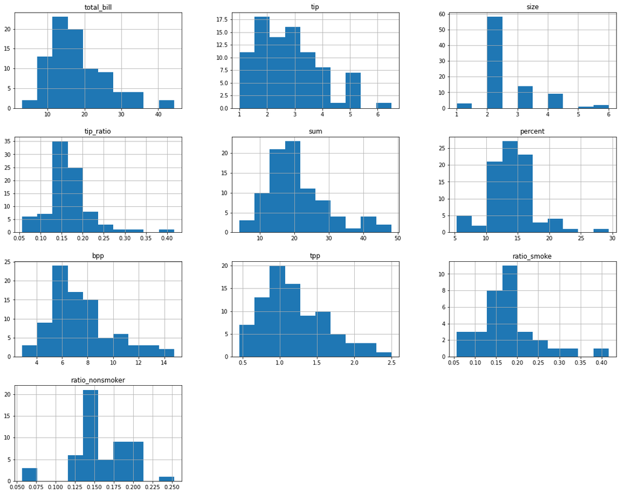

```python
# Graphical summary of the female customers
Female_tips.hist(figsize=(20,16))
```

```python
# Numerical summary of the female customers
Female_tips.describe()
```

|  | total_bill | tip | size | tip_ratio | sum | percent | bpp | tpp | ratio_smoke | ratio_nonsmoker |
| --- | --- | --- | --- | --- | --- | --- | --- | --- | --- | --- |
| count | 87.000000 | 87.000000 | 87.000000 | 87.000000 | 87.000000 | 87.000000 | 87.000000 | 87.000000 | 33.000000 | 54.000000 |
| mean | 18.056897 | 2.833448 | 2.459770 | 0.166491 | 20.890345 | 14.101724 | 7.463918 | 1.194603 | 0.182150 | 0.156921 |
| std | 8.009209 | 1.159495 | 0.937644 | 0.053632 | 8.841798 | 3.781743 | 2.461519 | 0.428018 | 0.071595 | 0.036421 |
| min | 3.070000 | 1.000000 | 1.000000 | 0.056433 | 4.070000 | 5.340000 | 2.875000 | 0.453333 | 0.056433 | 0.056797 |
| 25% | 12.750000 | 2.000000 | 2.000000 | 0.140416 | 14.870000 | 12.315000 | 5.682500 | 0.920000 | 0.152439 | 0.139708 |
| 50% | 16.400000 | 2.750000 | 2.000000 | 0.155581 | 18.900000 | 13.460000 | 6.710000 | 1.115000 | 0.173913 | 0.149691 |
| 75% | 21.520000 | 3.500000 | 3.000000 | 0.194266 | 25.000000 | 16.265000 | 8.721250 | 1.470000 | 0.198216 | 0.181630 |
| max | 44.300000 | 6.500000 | 6.000000 | 0.416667 | 48.110000 | 29.410000 | 14.766667 | 2.500000 | 0.416667 | 0.252672 |

For the females:

- The highest amount customers paid(excluding the tips) in the resturant was 44.3 Euros and the minimum amount was 3.07 Euros.
- The maximum amount of tips paid by customer was Euros while 6.5 the minimum tip paid was 1 euros.

```python
# Getting the unique values for female smokers and non-smokers
print(female_tips.smoker.value_counts())
```

```
No     54
Yes    33
Name: smoker, dtype: int64
```

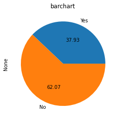

```python
# Graphical representation of the unique values
female_tips.groupby('smoker').size().plot(kind='pie', autopct='%.2f', title = "barchart")
```

> 62.07% of the females are non-smokers, while 37.93% are smokers

```
<BarContainer object of 4 artists>
```

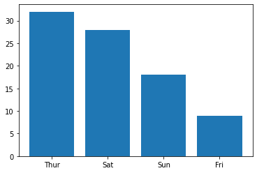

```python
# Craeting a bar chart to determine which day did the females mostly paid tips
plt.bar(female_tips['day'].value_counts().index,female_tips['day'].value_counts().values)
```

> The females mostly paid tips on Thursday

```
<BarContainer object of 2 artists>
```

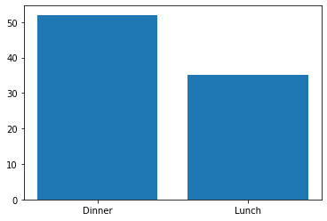

```python
# Craeting a bar chart to determine which period did the females mostly paid tips
plt.bar(female_tips['time'].value_counts().index,female_tips['time'].value_counts().values)
```

> The females mostly paid tips during dinner time

```python
# # Subsetting the data to have only male customers
male_tips = tips.loc[tips.sex == 'Male']
male_tips.head()
```

|  | total_bill | tip | sex | smoker | day | time | size | tip_ratio | sum | percent | bpp | tpp | ratio_smoke | ratio_nonsmoker |
| --- | --- | --- | --- | --- | --- | --- | --- | --- | --- | --- | --- | --- | --- | --- |
| 1 | 10.34 | 1.66 | Male | No | Sun | Dinner | 3 | 0.160542 | 12.00 | 13.83 | 3.446667 | 0.553333 | NaN | 0.160542 |
| 2 | 21.01 | 3.50 | Male | No | Sun | Dinner | 3 | 0.166587 | 24.51 | 14.28 | 7.003333 | 1.166667 | NaN | 0.166587 |
| 3 | 23.68 | 3.31 | Male | No | Sun | Dinner | 2 | 0.139780 | 26.99 | 12.26 | 11.840000 | 1.655000 | NaN | 0.139780 |
| 5 | 25.29 | 4.71 | Male | No | Sun | Dinner | 4 | 0.186240 | 30.00 | 15.70 | 6.322500 | 1.177500 | NaN | 0.186240 |
| 6 | 8.77 | 2.00 | Male | No | Sun | Dinner | 2 | 0.228050 | 10.77 | 18.57 | 4.385000 | 1.000000 | NaN | 0.228050 |

```
array([[<AxesSubplot:title={'center':'total_bill'}>,
        <AxesSubplot:title={'center':'tip'}>,
        <AxesSubplot:title={'center':'size'}>],
       [<AxesSubplot:title={'center':'tip_ratio'}>,
        <AxesSubplot:title={'center':'sum'}>,
        <AxesSubplot:title={'center':'percent'}>],
       [<AxesSubplot:title={'center':'bpp'}>,
        <AxesSubplot:title={'center':'tpp'}>,
        <AxesSubplot:title={'center':'ratio_smoke'}>],
       [<AxesSubplot:title={'center':'ratio_nonsmoker'}>, <AxesSubplot:>,
        <AxesSubplot:>]], dtype=object)
```

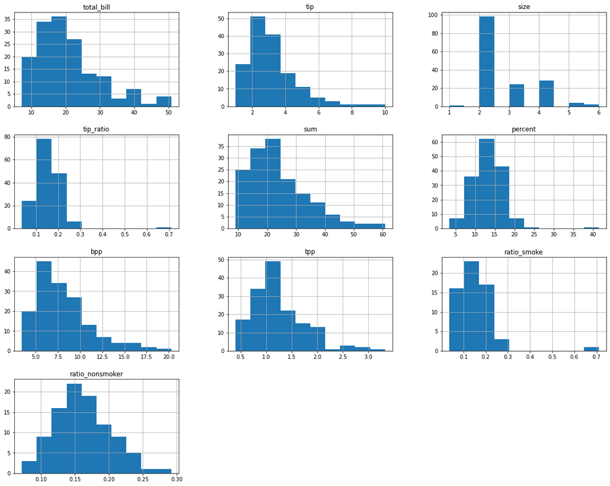

```python
# Graphical summary of the male customers
male_tips.hist(figsize=(20,16))
```

```python
# numerical summary of the male customers
male_tips.describe()
```

|  | total_bill | tip | size | tip_ratio | sum | percent | bpp | tpp | ratio_smoke | ratio_nonsmoker |
| --- | --- | --- | --- | --- | --- | --- | --- | --- | --- | --- |
| count | 157.000000 | 157.000000 | 157.000000 | 157.000000 | 157.000000 | 157.000000 | 157.000000 | 157.000000 | 60.000000 | 97.000000 |
| mean | 20.744076 | 3.089618 | 2.630573 | 0.157651 | 23.833694 | 13.389299 | 8.123358 | 1.222824 | 0.152771 | 0.160669 |
| std | 9.246469 | 1.489102 | 0.955997 | 0.064778 | 10.303309 | 4.194238 | 3.119912 | 0.524718 | 0.090588 | 0.041849 |
| min | 7.250000 | 1.000000 | 1.000000 | 0.035638 | 9.000000 | 3.440000 | 3.446667 | 0.400000 | 0.035638 | 0.071804 |
| 25% | 14.000000 | 2.000000 | 2.000000 | 0.121389 | 16.570000 | 10.820000 | 5.863333 | 0.833333 | 0.101845 | 0.131810 |
| 50% | 18.350000 | 3.000000 | 2.000000 | 0.153492 | 21.770000 | 13.310000 | 7.600000 | 1.085000 | 0.141015 | 0.157604 |
| 75% | 24.710000 | 3.760000 | 3.000000 | 0.186240 | 29.670000 | 15.700000 | 9.682500 | 1.500000 | 0.191697 | 0.186220 |
| max | 50.810000 | 10.000000 | 6.000000 | 0.710345 | 60.810000 | 41.530000 | 20.275000 | 3.333333 | 0.710345 | 0.291990 |

For the males:

- The highest amount customers paid(excluding the tips) in the resturant was 50.81 Euros and the minimum amount was 7.25 Euros.
- The maximum amount of tips paid by customer was Euros while 10 the minimum tip paid was 1 euros.

```python
# Getting the unique values for male smokers and non-smokers
print(male_tips.smoker.value_counts())
```

```
No     97
Yes    60
Name: smoker, dtype: int64
```

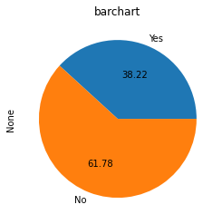

```python
# Graphical representation of the unique values
male_tips.groupby('smoker').size().plot(kind='pie', autopct='%.2f', title = "barchart")
```

```
<BarContainer object of 4 artists>
```

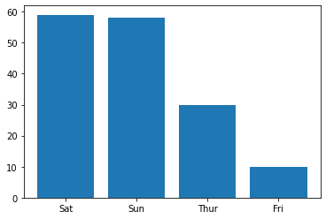

```python
# Craeting a bar chart to determine which day did the males mostly paid tips
plt.bar(male_tips['day'].value_counts().index,male_tips['day'].value_counts().values)
```

> The males mostly paid tips on Saturday

```
<BarContainer object of 2 artists>
```

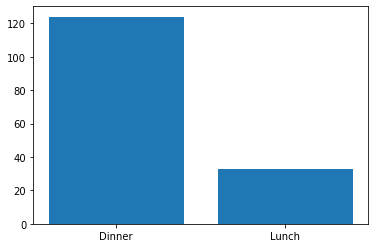

```python
# Craeting a bar chart to determine which period did the males mostly paid tips
plt.bar(male_tips['time'].value_counts().index,male_tips['time'].value_counts().values)
```

> The males mostly paid tips during dinner time.

```python
# Saving the data set to csv
tips.to_csv('tips.csv')
```